# bike_selling

authour

2023-11-30

The research question Is there a relationship between income and the likelihood of purchasing a bike ? The following factors or parameters from the dataset can be utilized to ascertain the connection between income and the probability of buying a bike: 1. Income: One predictor variable that can be used is the person’s income level. It makes sense that those who earn more money would be more likely to buy a bike since they might have more money available for other uses, such transportation and recreation. 2. Likelihood of buying a bike: This variable indicates the likelihood that a person will buy a bike. It might be utilized as the dependent variable in order to ascertain how revenue and it are related.

Data-driven, computational approach may be useful Because a data-driven, computational method makes it possible to analyze a lot of data and find patterns and interactions between variables, it might be helpful in addressing the research topic. In this instance, the methodology can assist in ascertaining whether income and the probability of buying a bike are significantly correlated.

The data can be evaluated to develop a predictive model that quantifies the association between income and the possibility of buying a bike by applying computer techniques like logistic regression. To further understand the influence of income on the purchasing choice, the model can incorporate additional factors like age, gender, education, occupation, and marital status. A data-driven, computational approach may be useful in addressing the research topic since it enables the analysis of large amounts of data and the discovery of patterns and relationships between variables. In this case, the technique can help determine whether there is a substantial correlation between income and the likelihood of purchasing a bike.

```r
library(tidyverse)
library(dplyr)

df <- read_csv("C:/Users/samso/Desktop/DATASETSS/bike_buyers.csv")
head(df)
```

```
## # A tibble: 6 × 13
##      ID `Marital Status` Gender Income Children Education       Occupation
##   <dbl> <chr>            <chr>   <dbl>    <dbl> <chr>           <chr>
## 1 12496 Married          Female  40000        1 Bachelors       Skilled Manual
## 2 24107 Married          Male    30000        3 Partial College Clerical
## 3 14177 Married          Male    80000        5 Partial College Professional
## 4 24381 Single           <NA>    70000        0 Bachelors       Professional
## 5 25597 Single           Male    30000        0 Bachelors       Clerical
## 6 13507 Married          Female  10000        2 Partial College Manual
## # ℹ 6 more variables: `Home Owner` <chr>, Cars <dbl>, `Commute Distance` <chr>,
## #   Region <chr>, Age <dbl>, `Purchased Bike` <chr>
```

Computational Method

The necessary data wrangling steps to make the data ready for subsequent analyses Handling null values

```r
sum(is.na(df))
```

```
## [1] 53
```

```r
dim(df)
```

```
## [1] 1000   13
```

```r
#renaming column
df <- df %>% rename(Purchased_Bike = "Purchased Bike")

df_clean <- na.omit(df)

head(df_clean)
```

```
## # A tibble: 6 × 13
##      ID `Marital Status` Gender Income Children Education       Occupation
##   <dbl> <chr>            <chr>   <dbl>    <dbl> <chr>           <chr>
## 1 12496 Married          Female  40000        1 Bachelors       Skilled Manual
## 2 24107 Married          Male    30000        3 Partial College Clerical
## 3 14177 Married          Male    80000        5 Partial College Professional
## 4 25597 Single           Male    30000        0 Bachelors       Clerical
## 5 13507 Married          Female  10000        2 Partial College Manual
## 6 19364 Married          Male    40000        1 Bachelors       Skilled Manual
## # ℹ 6 more variables: `Home Owner` <chr>, Cars <dbl>, `Commute Distance` <chr>,
## #   Region <chr>, Age <dbl>, Purchased_Bike <chr>
```

```r
summary(df_clean)
```

```
##        ID        Marital Status        Gender              Income
##  Min.   :11000   Length:952         Length:952         Min.   : 10000
##  1st Qu.:15310   Class :character   Class :character   1st Qu.: 30000
##  Median :19748   Mode  :character   Mode  :character   Median : 60000
##  Mean   :19980                                         Mean   : 55903
##  3rd Qu.:24532                                         3rd Qu.: 70000
##  Max.   :29447                                         Max.   :170000
##     Children      Education          Occupation         Home Owner
##  Min.   :0.000   Length:952         Length:952         Length:952
##  1st Qu.:0.000   Class :character   Class :character   Class :character
##  Median :2.000   Mode  :character   Mode  :character   Mode  :character
##  Mean   :1.898
##  3rd Qu.:3.000
##  Max.   :5.000
##       Cars       Commute Distance      Region               Age
##  Min.   :0.000   Length:952         Length:952         Min.   :25.00
##  1st Qu.:1.000   Class :character   Class :character   1st Qu.:35.00
##  Median :1.000   Mode  :character   Mode  :character   Median :43.00
##  Mean   :1.453                                         Mean   :44.26
##  3rd Qu.:2.000                                         3rd Qu.:52.00
##  Max.   :4.000                                         Max.   :89.00
##  Purchased_Bike
##  Length:952
##  Class :character
##  Mode  :character
##
##
##
```

The “Purchased_Bike” variable in the above code snippet needs to be changed from a string (“Yes” or “No”) to a numeric form in order to produce the binary indicator variable “Purchased_numeric”. When a customer purchases a bike, this variable assigns a value of 1, and when they don’t, it assigns a value of 0. With the use of this numerical representation, we can examine and improve the interpretability of our models and make it easier to use other machine learning algorithms that can work with numeric data by transforming categorical variables into numerical form. In order to optimize model performance and derive significant insights from the data, this transformation is essential.

```r
#convert from string to numeric
df_clean$Purchased_numeric <- ifelse(df_clean$Purchased_Bike == "Yes", 1, 0)
#What exploratory analyses and modeling techniques can be used to answer the research
#questions?
summary(df_clean$Income)
```

```
##    Min. 1st Qu.  Median    Mean 3rd Qu.    Max.
##   10000   30000   60000   55903   70000  170000
```

## Including Plots

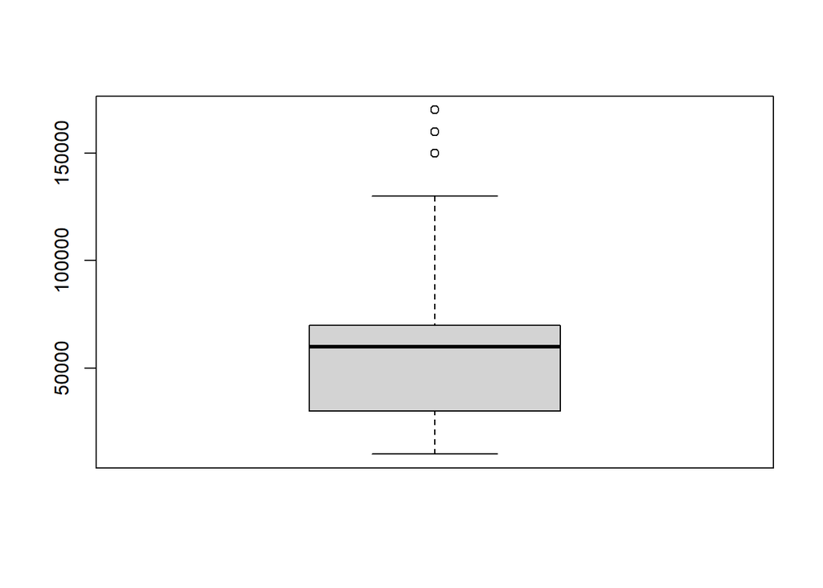

With the income range on the x-axis and the frequency on the y-axis, the histogram displays the frequency of each income range. Additionally, the histogram demonstrates the right-skewed income distribution, which indicates that there are more individuals with lower incomes than with higher incomes.

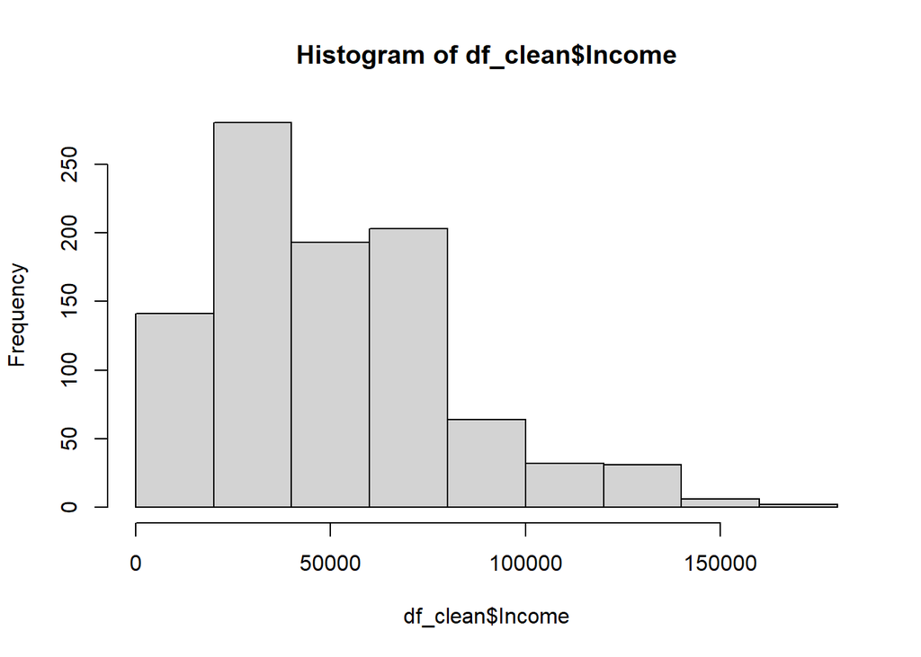

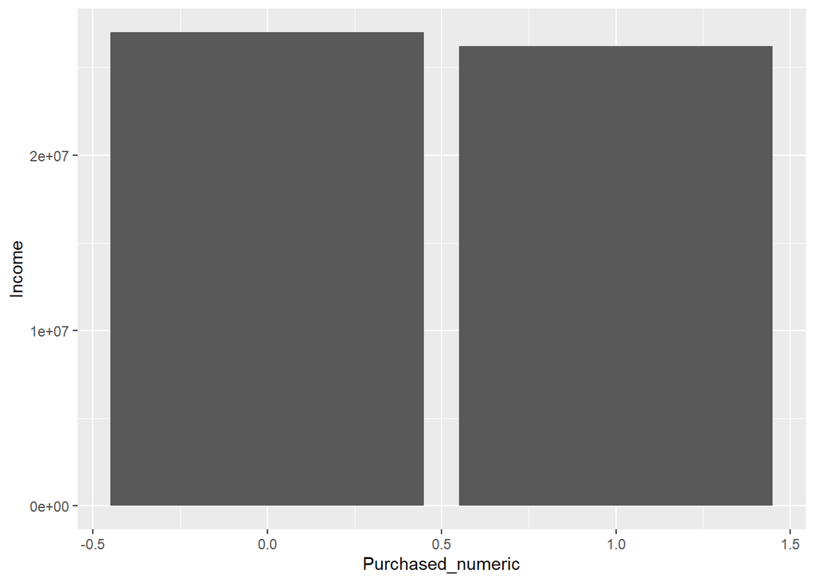

```
## # A tibble: 6 × 4
##   Income   Age Children Purchased_numeric
##    <dbl> <dbl>    <dbl>             <dbl>
## 1  40000    42        1                 0
## 2  30000    43        3                 0
## 3  80000    60        5                 0
## 4  30000    36        0                 1
## 5  10000    50        2                 0
## 6  40000    43        1                 1
```